# Algoritmos

Eugenio Alastra

2026-04-01

## R Markdown

This is an R Markdown document. Markdown is a simple formatting syntax for authoring HTML, PDF, and MS Word documents. For more details on using R Markdown see http://rmarkdown.rstudio.com. When you click the *Knit* button a document will be generated that includes both content as well as the output of any embedded R code chunks within the document. You can embed an R code chunk like this: ## Primeros comandos de R R es un legunaje muy parecido a matlab y trabaja generalmente con variables que pueden ser matrices. Para escribir un código oprimimos la tecla +C en verde y R.

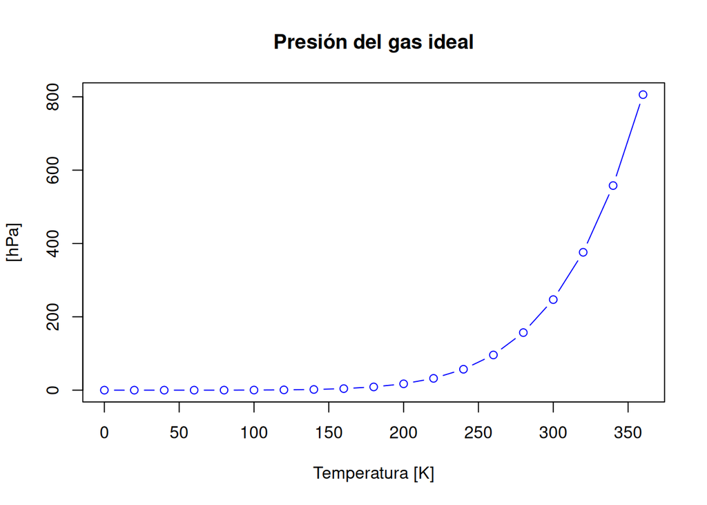

```r
plot(pressure,main="Presión del gas ideal",ylab="Presión
[hPa]",xlab="Temperatura [K]",type="b", col="blue")
```

```r
a=38
a=40
b=60
c=b-a
c
```

```
## [1] 20
```

```r
Y=40
alpha<-30
```

## Uso de data sets o base de datos internos de R

Usando el comando data en la consola obtenemos un listado de distintos datos ya cargados en la base de datos de R. Estos datos están dados en tablas/matrices de las cuales podemos elegir columnas específicas si escribimos signo pesos después del comando de información especifíco. Por ejemplo cars$speed. Nos saltan todas la velocidades que antes la encontrabamos en forma de columna en la matriz de cars. ### Conclusion El uso de Posit Cloud representa una solución práctica y accesible para iniciarse en el análisis de datos con R, especialmente en entornos académicos y colaborativos. Su facilidad de acceso, sin necesidad de instalaciones complejas, favorece el aprendizaje y el trabajo en equipo desde cualquier lugar. No obstante, al depender de internet y contar con recursos limitados, puede no ser la opción más adecuada para proyectos de gran escala o que requieran alto rendimiento computacional. En consecuencia, se posiciona como una herramienta ideal para la formación, la experimentación y el desarrollo de proyectos intermedios, mientras que los trabajos más exigentes pueden beneficiarse de un entorno local más robusto. ### Tabla comparativa: Posit Cloud vs R local

| Característica | Posit Cloud | R local (instalado en PC) |
| --- | --- | --- |
| Instalación | No requiere instalación de R y RStudio | Requiere instalación de R y RStudio |
| Acceso | Desde cualquier dispositivo con internet | Solo desde la computadora instalada |
| Conexión a internet | Obligatoria | No obligatoria |
| Recursos computacionales | Limitados (según el plan) | Dependen del hardware de la PC |
| Rendimiento | Adecuado para proyectos pequeños/medianos | Mejor para proyectos grandes o pesados |
| Trabajo colaborativo | Muy sencillo (compartir proyectos online) | Requiere herramientas externas como Git |
| Actualizaciones | Automáticas | Dependen del usuario |
| Ideal para | Aprendizaje y prototipado | Trabajo profesional y análisis intensivo |

### Data set en R

```r
data()
data(iris)
```